# Impact analysis on US public health and economy caused by storms and other severe weather events

Paolo Guderzo

20 gennaio 2019

## 1. Synopsis

In this report we aim to analyze the impact on US public health and economy caused by storms and other severe weather events.

We will use data coming from the U.S. National Oceanic and Atmospheric Administration’s (NOAA) storm database. The database covers the time period between 1950 and November 2011. In the earlier years of the database there are generally fewer events recorded, most likely due to a lack of good records. More recent years should be considered more complete.

The report will try to address two questions:

- which type of events are most harmful with respect to population health;
- which type of events have the greatest economic consequences - property and agriculture (i.e. crops).

## 2. Data processing

The data can be downloaded from the Course Website: [Storm Data](https://d396qusza40orc.cloudfront.net/repdata%2Fdata%2FStormData.csv.bz2). Documentation about the database can be found at the following links:

- National Weather Service: [Storm Data Documentation](https://d396qusza40orc.cloudfront.net/repdata%2Fpeer2_doc%2Fpd01016005curr.pdf)
- National Climatic Data Center Storm Events: [FAQ](https://d396qusza40orc.cloudfront.net/repdata%2Fpeer2_doc%2FNCDC%20Storm%20Events-FAQ%20Page.pdf)

### 2.1 Unzip, load and prepare data

#### 2.1.1 Setting Global Options

```r
knitr::opts_chunk$set(echo = TRUE, results = "asis", warning = FALSE, message = TRUE)
```

#### 2.1.2 Loading R packages

```r
library(plyr)
library(dplyr)
library(ggplot2)
library(R.utils)
library(gridExtra)
```

#### 2.1.3 Unzip the file

```r
workingDirectory <- getwd()
zipDataFile <- "repdata_data_StormData.csv.bz2"
dataFile <- "repdata_data_StormData.csv"
if(!file.exists(dataFile)){
    bunzip2(zipDataFile, dataFile, remove = FALSE)
}
```

#### 2.1.4 Read and load the data

```r
fullData <- read.table(file.path(workingDirectory,
            dataFile),
            header = TRUE,
            sep = ",",
            stringsAsFactors=FALSE)
```

#### 2.1.5 Subset data in order to manage only the necessary information about health and economic aspects involved by storms and other severe weather events

```r
fullDataRed <- fullData[,c("EVTYPE", "FATALITIES", "INJURIES", "PROPDMG","PROPDMGEXP","CROPDMG","CROPDMGEXP")]
```

#### 2.1.6 Apply toupper function to all columns containing character values (EVTYPE, PROPDMGRXP, CROPDMGEXP) in order to have all of them in capital letters

```r
fullDataRed$EVTYPE <- toupper(fullDataRed$EVTYPE)
fullDataRed$PROPDMGEXP <- toupper(fullDataRed$PROPDMGEXP)
fullDataRed$CROPDMGEXP <- toupper(fullDataRed$CROPDMGEXP)
```

### 2.2 Public health problems - prepare data for plotting

#### 2.2.1 Sum fatalities and injuries by event type; then order data in descending order for plotting

```r
publicHealthData <- ddply(fullDataRed, .(EVTYPE), summarize, groupByFatalities = sum(FATALITIES),groupByInjuries = sum(INJURIES))

groupByFatalitiesDesc <- arrange(publicHealthData, desc(groupByFatalities))
# Delete unuseful column (groupByInjuries)
groupByFatalitiesDesc <- subset(groupByFatalitiesDesc, select = -groupByInjuries)

groupByInjuriesDesc <- arrange(publicHealthData, desc(groupByInjuries))
# Delete unuseful column (groupByFatalities)
groupByInjuriesDesc <- subset(groupByInjuriesDesc, select = -groupByFatalities)
```

### 2.3 Economic problems - prepare data for plotting

#### 2.3.1 Compute the economic values using a function that correctly interprets the exponential codes stored in the PROPDMGEXP and CROPDMGEXP columns

1. Define a function to use for the correction of the exponential codes

```r
correctExp <- function(expValue)
{
    correctExpValue <- 0
    if (expValue == "H")
        {
        correctExpValue <- 2
        return(correctExpValue)
        }
    else if (expValue == "K")
        {
        correctExpValue <- 3
        return(correctExpValue)
        }
    else if (expValue == "M")
        {
        correctExpValue <- 6
        return(correctExpValue)
        }
    else if (expValue == "B")
        {
        correctExpValue <- 9
        return(correctExpValue)
        }
    else if (expValue %in% c("", "-", "?", "+"))
        {
        correctExpValue <- 0
        return(correctExpValue)
        }
    else if (!is.na(as.numeric(expValue)))
        {
        correctExpValue <- as.numeric(expValue)
        return(correctExpValue)
        }
    else
        {
        stop("Input value not managed")
        }
}
```

2. Apply this function to update both PROPDMGEXP and CROPDMGEXP variables

```r
fullDataRed$PROPDMGEXP <- sapply(fullDataRed$PROPDMGEXP, correctExp)
fullDataRed$CROPDMGEXP <- sapply(fullDataRed$CROPDMGEXP, correctExp)
```

3. Compute the economic damage amount for both PROPDMG and CROPDMG variables, adding two new variables

```r
fullDataRed$PropDmgAmt <- fullDataRed$PROPDMG * (10 ** fullDataRed$PROPDMGEXP)
fullDataRed$CropDmgAmt <- fullDataRed$CROPDMG * (10 ** fullDataRed$CROPDMGEXP)
```

#### 2.3.2 Sum properties and crops damages by event type; then order data in descending order for plotting

```r
economicData <- ddply(fullDataRed, .(EVTYPE), summarize, groupByProperties = sum(PropDmgAmt), groupByCrops = sum(CropDmgAmt))

groupByPropertiesDesc <- arrange(economicData, desc(groupByProperties))
# Delete unuseful column (groupByProperties)
groupByPropertiesDesc <- subset(groupByPropertiesDesc, select = -groupByCrops)

groupByCropsDesc <- arrange(economicData, desc(groupByCrops))
# Delete unuseful column (groupByCrops)
groupByCropsDesc <- subset(groupByCropsDesc, select = -groupByProperties)
```

## 3. Results

### 3.1 Ten top events with the most dangerous effects on population health

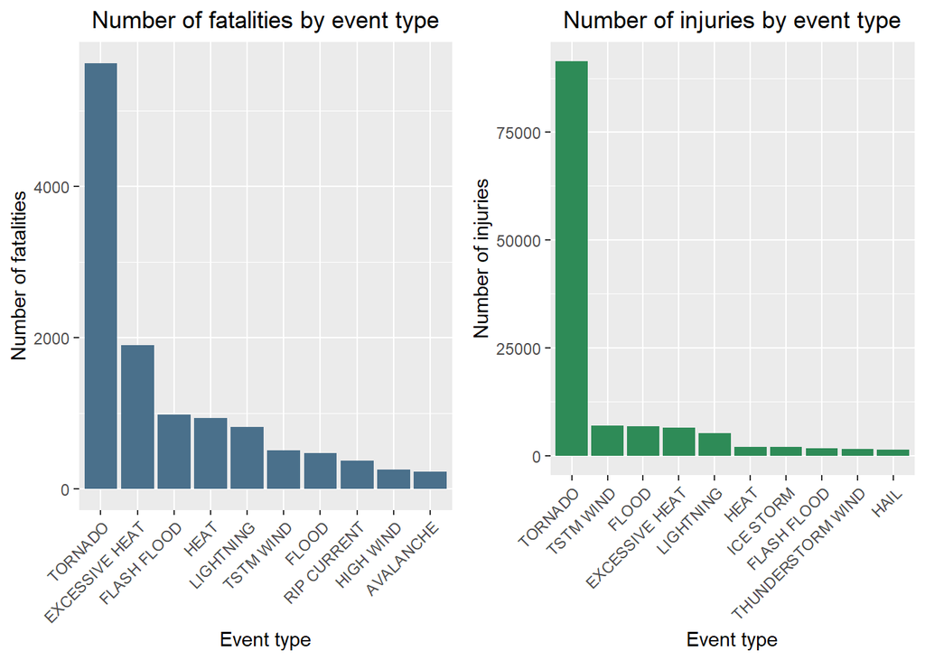

```r
# Create fatalities chart - Select top ten events
fatalitiesChart <- ggplot(data=head(groupByFatalitiesDesc,10), aes(x=reorder(EVTYPE, -groupByFatalities), y=groupByFatalities))

# Define the type of the chart - Use stat = "identity" that leaves the data as is
fatalitiesChart = fatalitiesChart + geom_bar(stat="identity", fill = "skyblue4")

# Set y-axis label
fatalitiesChart = fatalitiesChart + ylab("Number of fatalities")

# Set x-axis label
fatalitiesChart = fatalitiesChart + xlab("Event type")
fatalitiesChart = fatalitiesChart + theme(axis.text.x = element_text(angle = 45, hjust = 1))

# Set chart title
fatalitiesChart = fatalitiesChart + ggtitle("Number of fatalities by event type") + theme(plot.title = element_text(hjust = 0.5))
fatalitiesChart = fatalitiesChart + theme(legend.position="none")


# Create injuries chart - Select top ten events
injuriesChart <- ggplot(data=head(groupByInjuriesDesc,10), aes(x=reorder(EVTYPE, -groupByInjuries), y=groupByInjuries))

# Define the type of the chart - Use stat = "identity" that leaves the data as is
injuriesChart = injuriesChart + geom_bar(stat="identity", fill = "seagreen")

# Set y-axis label
injuriesChart = injuriesChart + ylab("Number of injuries")

# Set x-axis label
injuriesChart = injuriesChart + xlab("Event type")
injuriesChart = injuriesChart + theme(axis.text.x = element_text(angle = 45, hjust = 1))

# Set chart title
injuriesChart = injuriesChart + ggtitle("Number of injuries by event type") + theme(plot.title = element_text(hjust = 0.5))
injuriesChart = injuriesChart + theme(legend.position="none")


# Prepare for plotting charts
grid.arrange(fatalitiesChart, injuriesChart, nrow = 1)
```

### 3.2 Ten top events with the most dangerous effects on economy

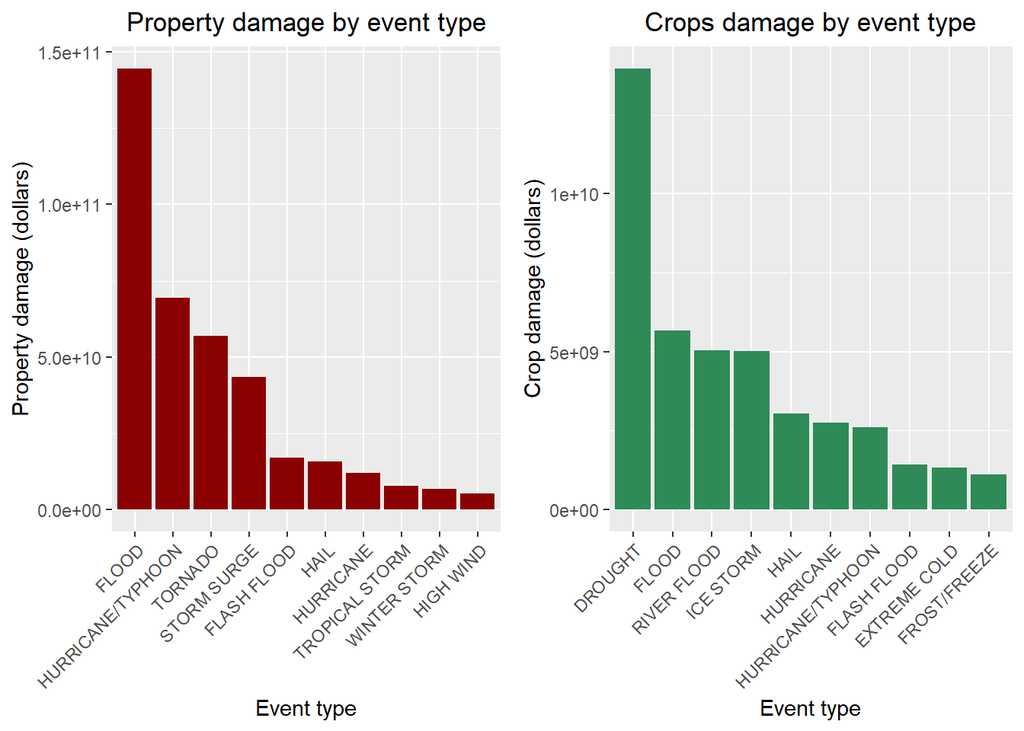

```r
# Create properties chart - Select top ten events
propertiesChart <- ggplot(data=head(groupByPropertiesDesc,10), aes(x=reorder(EVTYPE, -groupByProperties), y=groupByProperties))

# Define the type of the chart - Use stat = "identity" that leaves the data as is
propertiesChart = propertiesChart + geom_bar(stat="identity", fill = "red4")

# Set y-axis label
propertiesChart = propertiesChart + ylab("Property damage (dollars)")

# Set x-axis label
propertiesChart = propertiesChart + xlab("Event type")
propertiesChart = propertiesChart + theme(axis.text.x = element_text(angle = 45, hjust = 1))

# Set chart title
propertiesChart = propertiesChart + ggtitle("Property damage by event type") + theme(plot.title = element_text(hjust = 0.5))
propertiesChart = propertiesChart + theme(legend.position="none")


# Create crops chart - Select top ten events
cropsChart <- ggplot(data=head(groupByCropsDesc,10), aes(x=reorder(EVTYPE, -groupByCrops), y=groupByCrops))

# Define the type of the chart - Use stat = "identity" that leaves the data as is
cropsChart = cropsChart + geom_bar(stat="identity", fill = "seagreen")

# Set y-axis label
cropsChart = cropsChart + ylab("Crop damage (dollars)")

# Set x-axis label
cropsChart = cropsChart + xlab("Event type")
cropsChart = cropsChart + theme(axis.text.x = element_text(angle = 45, hjust = 1))

# Set chart title
cropsChart = cropsChart + ggtitle("Crops damage by event type") + theme(plot.title = element_text(hjust = 0.5))
cropsChart = cropsChart + theme(legend.position="none")


# Prepare for plotting charts
grid.arrange(propertiesChart, cropsChart, nrow = 1)
```

**Comments** Overall, floods cause the most relevant economic consequences, even if drought is by far the most damaging event for crops.

**Warning** The EVTYPE variable has 898 unique values but lots of them are similar. In many cases, they differ each other because of:

- a blank before the event type (ie “COASTAL FLOOD”, " COASTAL FLOOD“)
- one or more character (ie “BEACH EROSIN”, “BEACH EROSION”)
- different description for the same event (ie “FLASH FLOOD/FLOOD”, “FLASH FLOOD/ FLOOD”, “FLASH FLOODING/FLOOD”)
- etc ..

In other situations, the EVTYPE is not clear (ie “EXCESSIVE”) .. and so on. Surely a data cleansing step designed to correct these situations BEFORE to analyze the data is appropriated.